# 7 Work with Date and Time - lubridate

Jiuru Lyu

2022-11-15

# Importing Packages

```r
library(tidyverse)
library(nycflights13)
library(lubridate)
```

# `lubridate`

This lab will focus on the `lubridate` package, which makes it easier to work with dates and times in R.

- Date:

```r
today()
```

```
## [1] "2022-11-15"
```

- Date-time

```r
now()
```

```
## [1] "2022-11-15 10:27:41 EST"
```

There are usually two ways you are likely to create a date/time:

1. From a string: Use the `lubridate` function to parse your date into R standard format

```r
ymd("2019-01-31")
```

```
## [1] "2019-01-31"
```

```r
mdy("January 31st, 2019")
```

```
## [1] "2019-01-31"
```

```r
dmy("31-Jan-2019")
```

```
## [1] "2019-01-31"
```

```r
ymd_hms("2019-01-31 20:11:59")
```

```
## [1] "2019-01-31 20:11:59 UTC"
```

```r
ymd_h("2019013120")
```

```
## [1] "2019-01-31 20:00:00 UTC"
```

2. From individual components: Use `make_date()` for dates or `make_datetime()` for date-time

```r
flights %>%
  select(year, month, day, hour, minute) %>%
  mutate(departure_sched = make_datetime(year, month, day, hour, minute)) %>%
  head(10)
```

```
## # A tibble: 10 × 6
##     year month   day  hour minute departure_sched
##    <int> <int> <int> <dbl>  <dbl> <dttm>
##  1  2013     1     1     5     15 2013-01-01 05:15:00
##  2  2013     1     1     5     29 2013-01-01 05:29:00
##  3  2013     1     1     5     40 2013-01-01 05:40:00
##  4  2013     1     1     5     45 2013-01-01 05:45:00
##  5  2013     1     1     6      0 2013-01-01 06:00:00
##  6  2013     1     1     5     58 2013-01-01 05:58:00
##  7  2013     1     1     6      0 2013-01-01 06:00:00
##  8  2013     1     1     6      0 2013-01-01 06:00:00
##  9  2013     1     1     6      0 2013-01-01 06:00:00
## 10  2013     1     1     6      0 2013-01-01 06:00:00
```

```r
make_datetime_100 <- function(year, month, day, time) {
  make_datetime(year, month, day, time %/% 100, time %% 100)
}

flights %>%
  filter(!is.na(dep_time), !is.na(arr_time)) %>%  # remove all cancelled fights
  mutate(
    dep_time = make_datetime_100(year, month, day, dep_time),
    arr_time = make_datetime_100(year, month, day, arr_time),
    sched_dep_time = make_datetime_100(year, month, day, sched_dep_time),
    sched_arr_time = make_datetime_100(year, month, day, sched_arr_time)
  ) %>%
  select(origin, dest, ends_with("delay"), ends_with("time")) %>%
  head(10)
```

```
## # A tibble: 10 × 9
##    origin dest  dep_delay arr_delay dep_time            sched_dep_time
##    <chr>  <chr>     <dbl>     <dbl> <dttm>              <dttm>
##  1 EWR    IAH           2        11 2013-01-01 05:17:00 2013-01-01 05:15:00
##  2 LGA    IAH           4        20 2013-01-01 05:33:00 2013-01-01 05:29:00
##  3 JFK    MIA           2        33 2013-01-01 05:42:00 2013-01-01 05:40:00
##  4 JFK    BQN          -1       -18 2013-01-01 05:44:00 2013-01-01 05:45:00
##  5 LGA    ATL          -6       -25 2013-01-01 05:54:00 2013-01-01 06:00:00
##  6 EWR    ORD          -4        12 2013-01-01 05:54:00 2013-01-01 05:58:00
##  7 EWR    FLL          -5        19 2013-01-01 05:55:00 2013-01-01 06:00:00
##  8 LGA    IAD          -3       -14 2013-01-01 05:57:00 2013-01-01 06:00:00
##  9 JFK    MCO          -3        -8 2013-01-01 05:57:00 2013-01-01 06:00:00
## 10 LGA    ORD          -2         8 2013-01-01 05:58:00 2013-01-01 06:00:00
## # … with 3 more variables: arr_time <dttm>, sched_arr_time <dttm>,
## #   air_time <dbl>
```

With this data, we can visualize the distribution of departure times across the year:

```r
flights_dt <- flights %>%
  filter(!is.na(dep_time), !is.na(arr_time)) %>%  # remove all cancelled fights
  mutate(
    dep_time = make_datetime_100(year, month, day, dep_time),
    arr_time = make_datetime_100(year, month, day, arr_time),
    sched_dep_time = make_datetime_100(year, month, day, sched_dep_time),
    sched_arr_time = make_datetime_100(year, month, day, sched_arr_time)
  ) %>%
  select(origin, dest, ends_with("delay"), ends_with("time"))
```

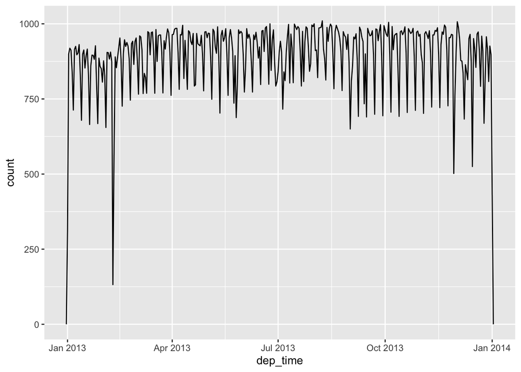

```r
flights_dt %>%
  ggplot(aes(dep_time)) +
  geom_freqpoly(binwidth = 86400) # 86400 seconds = 1 day
```

We can set the time interval into 10 minutes and zoom in to look at a smaller proportion of data:

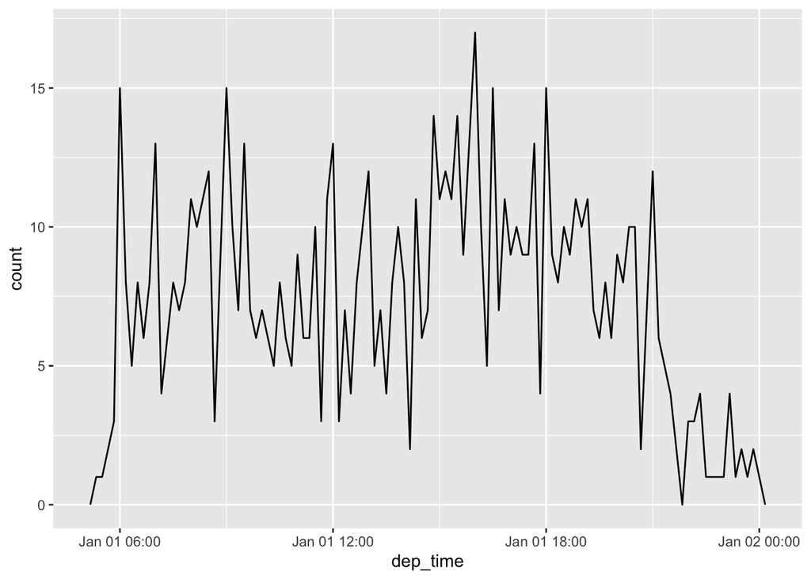

```r
flights_dt %>%
  filter(dep_time < ymd("20130102")) %>%
  ggplot(aes(dep_time)) +
  geom_freqpoly(binwidth = 600) # 600 s = 10 minutes
```

We can change the time interval:

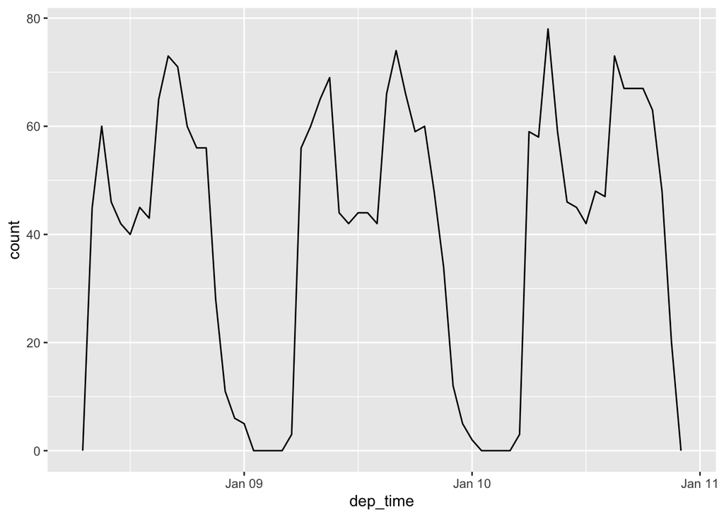

```r
flights_dt %>%
  filter(dep_time < ymd_hms("20130110210000") & dep_time > ymd_hm("201301080800")) %>%
  ggplot(aes(dep_time)) +
  geom_freqpoly(binwidth = 3600) # 600 s = 10 minutes
```

3. We can also pick up time components from the R standard time format.

```r
datetime <- ymd_hms("2016-07-08 12:34:56")
```

```r
year(datetime)
```

```
## [1] 2016
```

```r
month(datetime)
```

```
## [1] 7
```

If you want to have character values from `month()`, set `lable = TURE`.

```r
month(datetime, label = TRUE)  # return the abbreviated name of the month or weekday
```

```
## [1] Jul
## 12 Levels: Jan < Feb < Mar < Apr < May < Jun < Jul < Aug < Sep < ... < Dec
```

We can also print out what day it is in the month, year, or week.

```r
mday(datetime)   # day of the month
```

```
## [1] 8
```

```r
yday(datetime)   # day of the year
```

```
## [1] 190
```

```r
wday(datetime)
```

```
## [1] 6
```

Some calendars start from Monday, while others start from Sunday. To avoid confusion, it is better to report character values when reporting the day of the week.

```r
wday(datetime, label = TRUE, abbr = FALSE)   # day of the week
```

```
## [1] Friday
## 7 Levels: Sunday < Monday < Tuesday < Wednesday < Thursday < ... < Saturday
```

```r
minute(datetime)
```

```
## [1] 34
```

```r
second(datetime)
```

```
## [1] 56
```

*Example 1*: Use `wday()` to see the distribution of flights depart everyday of a week.

```r
flights_dt %>%
  mutate(wday = wday(dep_time, label = TRUE)) %>%
  count(wday)
```

```
## # A tibble: 7 × 2
##   wday      n
##   <ord> <int>
## 1 Sun   45583
## 2 Mon   49396
## 3 Tue   49226
## 4 Wed   48753
## 5 Thu   48565
## 6 Fri   48645
## 7 Sat   37895
```

*Example 2*: What is the best time of an hour to fly?

It could be the average departure delay time or the average arrival delay.

```r
flights_dt %>%
  mutate(minute = minute(dep_time)) %>%
  group_by(minute) %>%
  summarize(
    n = n(),
    avg_dep = mean(dep_delay, na.rm = TRUE),
    avg_arr = mean(arr_delay, na.rm = TRUE)
  ) %>%
  head(10)
```

```
## # A tibble: 10 × 4
##    minute     n avg_dep avg_arr
##     <int> <int>   <dbl>   <dbl>
##  1      0  7160    10.6    5.26
##  2      1  5256    13.9    8.94
##  3      2  5110    14.2    9.59
##  4      3  5105    14.2    9.19
##  5      4  4916    15.1   10.5
##  6      5  5106    13.9    8.82
##  7      6  4728    15.9   10.5
##  8      7  4673    15.6   10.3
##  9      8  4772    15.6   10.9
## 10      9  4821    15.7   10.7
```

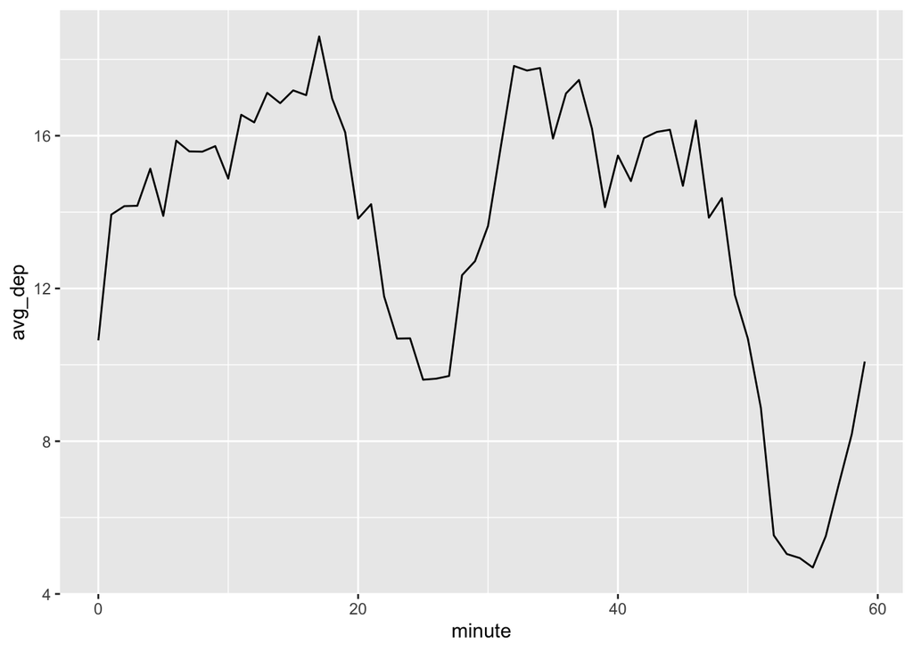

```r
flights_dt %>%
  mutate(minute = minute(dep_time)) %>%
  group_by(minute) %>%
  summarize(avg_dep = mean(dep_delay, na.rm = TRUE)) %>%
  ggplot(aes(x = minute, y = avg_dep)) + geom_line()
```

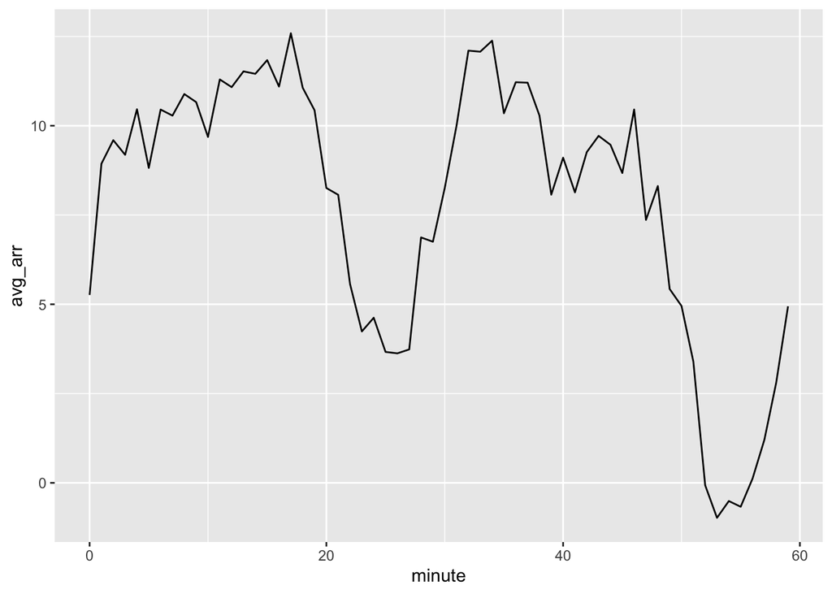

```r
flights_dt %>%
  mutate(minute = minute(dep_time)) %>%
  group_by(minute) %>%
  summarize(avg_arr = mean(arr_delay, na.rm = TRUE)) %>%
  ggplot(aes(x = minute, y = avg_arr)) + geom_line()
```

*Example 3*: Find the overnight flights:

```r
flights_dt %>%
  filter(arr_time < dep_time) %>%
  head(10)
```

```
## # A tibble: 10 × 9
##    origin dest  dep_delay arr_delay dep_time            sched_dep_time
##    <chr>  <chr>     <dbl>     <dbl> <dttm>              <dttm>
##  1 EWR    BQN           9        -4 2013-01-01 19:29:00 2013-01-01 19:20:00
##  2 JFK    DFW          59        NA 2013-01-01 19:39:00 2013-01-01 18:40:00
##  3 EWR    TPA          -2         9 2013-01-01 20:58:00 2013-01-01 21:00:00
##  4 EWR    SJU          -6       -12 2013-01-01 21:02:00 2013-01-01 21:08:00
##  5 EWR    SFO          11       -14 2013-01-01 21:08:00 2013-01-01 20:57:00
##  6 LGA    FLL         -10        -2 2013-01-01 21:20:00 2013-01-01 21:30:00
##  7 EWR    MCO          41        43 2013-01-01 21:21:00 2013-01-01 20:40:00
##  8 JFK    LAX          -7       -24 2013-01-01 21:28:00 2013-01-01 21:35:00
##  9 EWR    FLL          49        28 2013-01-01 21:34:00 2013-01-01 20:45:00
## 10 EWR    FLL          -9       -14 2013-01-01 21:36:00 2013-01-01 21:45:00
## # … with 3 more variables: arr_time <dttm>, sched_arr_time <dttm>,
## #   air_time <dbl>
```

These are overnight flights. We used the same date information for both the departure and the arrival times, but these flights arrived on the following day. We can fix this by adding days(1) to the arrival time of each overnight flight.

```r
flights_dt %>%
  mutate(
    overnight = arr_time < dep_time,
    arr_time = arr_time + days(overnight * 1),
    sched_arr_time = sched_arr_time + days(overnight * 1)
  ) %>%
  head(10)
```

```
## # A tibble: 10 × 10
##    origin dest  dep_delay arr_delay dep_time            sched_dep_time
##    <chr>  <chr>     <dbl>     <dbl> <dttm>              <dttm>
##  1 EWR    IAH           2        11 2013-01-01 05:17:00 2013-01-01 05:15:00
##  2 LGA    IAH           4        20 2013-01-01 05:33:00 2013-01-01 05:29:00
##  3 JFK    MIA           2        33 2013-01-01 05:42:00 2013-01-01 05:40:00
##  4 JFK    BQN          -1       -18 2013-01-01 05:44:00 2013-01-01 05:45:00
##  5 LGA    ATL          -6       -25 2013-01-01 05:54:00 2013-01-01 06:00:00
##  6 EWR    ORD          -4        12 2013-01-01 05:54:00 2013-01-01 05:58:00
##  7 EWR    FLL          -5        19 2013-01-01 05:55:00 2013-01-01 06:00:00
##  8 LGA    IAD          -3       -14 2013-01-01 05:57:00 2013-01-01 06:00:00
##  9 JFK    MCO          -3        -8 2013-01-01 05:57:00 2013-01-01 06:00:00
## 10 LGA    ORD          -2         8 2013-01-01 05:58:00 2013-01-01 06:00:00
## # … with 4 more variables: arr_time <dttm>, sched_arr_time <dttm>,
## #   air_time <dbl>, overnight <lgl>
```

*Example 4*: Find the average departure delay of each day of the week.

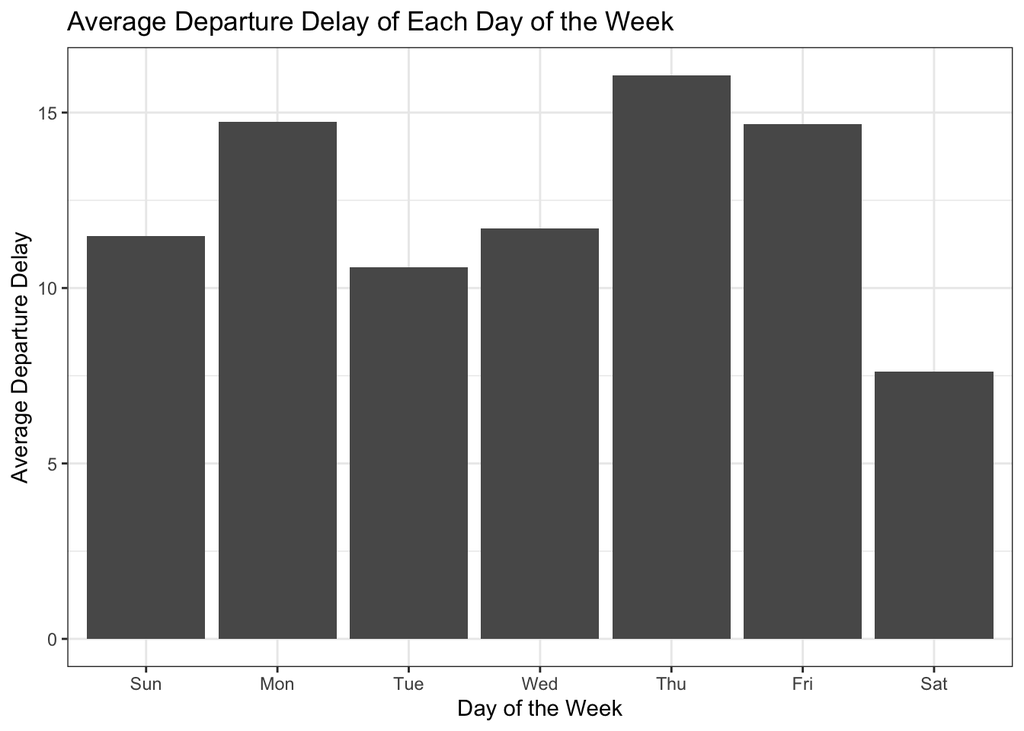

```r
flights_dt %>%
  mutate(wday = wday(dep_time, label = TRUE)) %>%
  group_by(wday) %>%
  summarize(avg_dep = mean(dep_delay, na.rm = TRUE)) %>%
  ggplot(aes(x = wday, y = avg_dep)) +
    geom_col() +
    labs(
      x = "Day of the Week",
      y = "Average Departure Delay",
      title = "Average Departure Delay of Each Day of the Week"
    ) +
    theme_bw()
```